# Praktikum 2 Visualisasi Data - Paralel 2

Cindy Indriyani

04 February 2026

# Load Data

```r
data <- read.csv("C:/Visualisasi Data Praktikum P2/patient_segmentation_dataset.csv", sep=",")
data <- as.data.frame(data)
head(data)
```

|  | PatientID | Age | Gender | State | City | Height_cm | Weight_kg | BMI | Insurance_Type | Primary_Condition | Num_Chronic_Conditions | Annual_Visits | Avg_Billing_Amount | Last_Visit_Date | Days_Since_Last_Visit | Preventive_Care_Flag |
| --- | --- | --- | --- | --- | --- | --- | --- | --- | --- | --- | --- | --- | --- | --- | --- | --- |
| 1 | P10000 | 64 | Male | GA | Unknown | 151 | 115 | 50.4 | Private | Arthritis | 3 | 7 | 2995.0 | 2025-07-18 | 186 | 0 |
| 2 | P10001 | 59 | Male | OH | Unknown | 189 | 68 | 19.0 | Medicare | Depression | 1 | 8 | 1209.0 | 2025-12-12 | 39 | 0 |
| 3 | P10002 | 58 | Female | PA | Unknown | 156 | 91 | 37.4 | Private | Asthma | 1 | 4 | 999.0 | 2025-09-16 | 126 | 0 |
| 4 | P10003 | 43 | Female | GA | Unknown | 152 | 92 | 39.8 | Medicare | Hypertension | 1 | 6 | 5638.5 | 2025-04-09 | 286 | 1 |
| 5 | P10004 | 53 | Female | NC | Unknown | 167 | 51 | 18.3 | Medicaid | Asthma | 1 | 4 | 5796.0 | 2025-03-07 | 319 | 0 |
| 6 | P10005 | 73 | Male | OH | Unknown | 160 | 120 | 46.9 | Medicare | Anxiety | 3 | 9 | 2397.5 | 2025-05-13 | 252 | 1 |

```r
str(data)
```

```
## 'data.frame':    2000 obs. of  16 variables:
##  $ PatientID             : chr  "P10000" "P10001" "P10002" "P10003" ...
##  $ Age                   : int  64 59 58 43 53 73 34 64 61 34 ...
##  $ Gender                : chr  "Male" "Male" "Female" "Female" ...
##  $ State                 : chr  "GA" "OH" "PA" "GA" ...
##  $ City                  : chr  "Unknown" "Unknown" "Unknown" "Unknown" ...
##  $ Height_cm             : int  151 189 156 152 167 160 161 177 171 182 ...
##  $ Weight_kg             : int  115 68 91 92 51 120 51 102 86 111 ...
##  $ BMI                   : num  50.4 19 37.4 39.8 18.3 46.9 19.7 32.6 29.4 33.5 ...
##  $ Insurance_Type        : chr  "Private" "Medicare" "Private" "Medicare" ...
##  $ Primary_Condition     : chr  "Arthritis" "Depression" "Asthma" "Hypertension" ...
##  $ Num_Chronic_Conditions: int  3 1 1 1 1 3 0 3 2 0 ...
##  $ Annual_Visits         : int  7 8 4 6 4 9 3 1 7 1 ...
##  $ Avg_Billing_Amount    : num  2995 1209 999 5638 5796 ...
##  $ Last_Visit_Date       : chr  "2025-07-18" "2025-12-12" "2025-09-16" "2025-04-09" ...
##  $ Days_Since_Last_Visit : int  186 39 126 286 319 252 223 252 251 11 ...
##  $ Preventive_Care_Flag  : int  0 0 0 1 0 1 1 0 1 0 ...
```

- PatientID: ID unik pasien (nomor identitas)
- Age: Umur pasien (tahun)
- Gender: Jenis kelamin (Male/Female)
- State: Negara bagian tempat tinggal (kode 2 huruf)
- City: Kota tempat tinggal
- Height_cm: Tinggi badan (centimeter)
- Weight_kg: Berat badan (kilogram)
- BMI: Indeks massa tubuh (Body Mass Index)
- Insurance_Type: Jenis asuransi kesehatan (Private/Medicare/Medicaid/Self Pay)
- Primary_Condition: Penyakit/kondisi utama pasien
- Num_Chronic_Conditions: Jumlah penyakit kronis yang diderita
- Annual_Visits: Jumlah kunjungan ke fasilitas kesehatan per tahun
- Avg_Billing_Amount: Rata-rata tagihan biaya kesehatan (dollar)
- Last_Visit_Date: Tanggal kunjungan terakhir
- Days_Since_Last_Visit: Jumlah hari sejak kunjungan terakhir
- Preventive_Care_Flag: Indikator perawatan pencegahan (0=tidak, 1=ya)

# Package

```r
library(ggplot2)   # Digunakan untuk visualisasi data berbasis Grammar of Graphics
library(ggridges)  # Digunakan untuk membuat ridge plot (joy plot) untuk membandingkan distribusi data antar kelompok
library(dplyr)     # Digunakan untuk manipulasi dan transformasi data (filter, select, mutate, summarise, group_by)
```

# Visualisasi Nilai Data

## Bar Chart

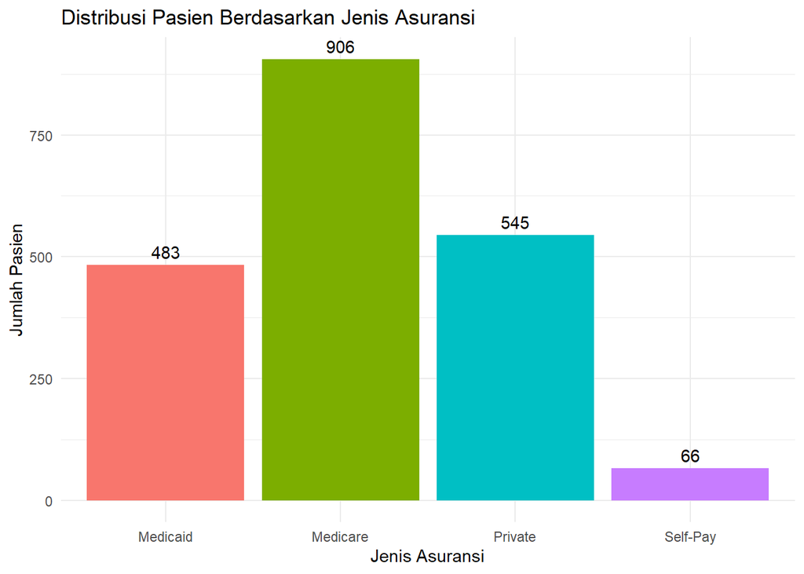

```r
ggplot(data, aes(x = Insurance_Type, fill = Insurance_Type)) +
  geom_bar() +
  geom_text(stat = 'count', aes(label = after_stat(count)), vjust = -0.5) +
  labs(title = "Distribusi Pasien Berdasarkan Jenis Asuransi",
       x = "Jenis Asuransi",
       y = "Jumlah Pasien") +
  theme_minimal() +
  theme(legend.position = "none")
```

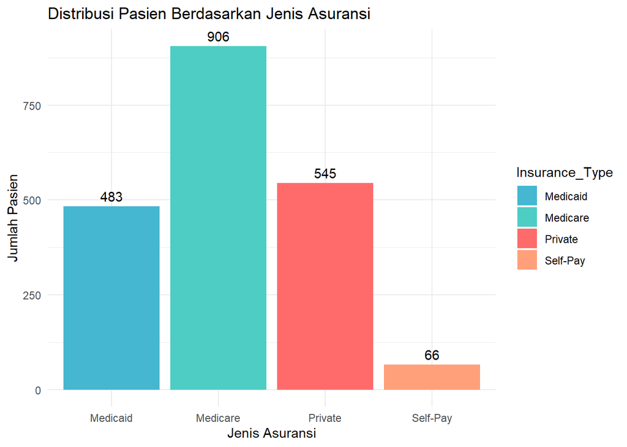

```r
# Kostum warna manual
ggplot(data, aes(x = Insurance_Type, fill = Insurance_Type)) +
  geom_bar() +
  geom_text(stat = 'count', aes(label = after_stat(count)), vjust = -0.5) +
  scale_fill_manual(values = c("Private" = "#FF6B6B",
                                "Medicare" = "#4ECDC4",
                                "Medicaid" = "#45B7D1",
                                "Self-Pay" = "#FFA07A")) +
  labs(title = "Distribusi Pasien Berdasarkan Jenis Asuransi",
       x = "Jenis Asuransi",
       y = "Jumlah Pasien") +
  theme_minimal()
```

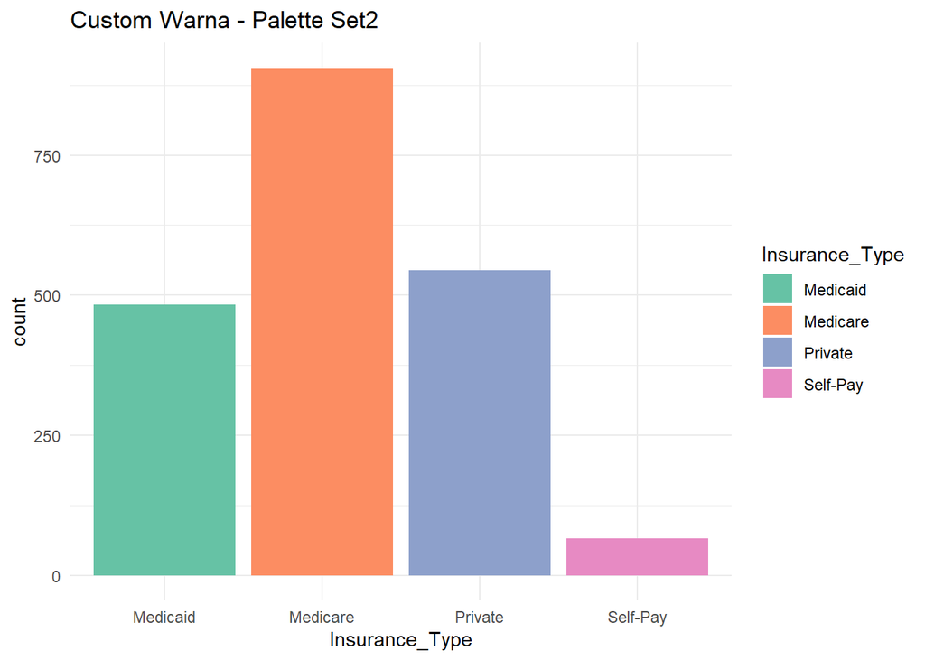

```r
# Warna bawaan R
ggplot(data, aes(x = Insurance_Type, fill = Insurance_Type)) +
  geom_bar() +
  scale_fill_brewer(palette = "Set2") +
  labs(title = "Custom Warna - Palette Set2") +
  theme_minimal()
```

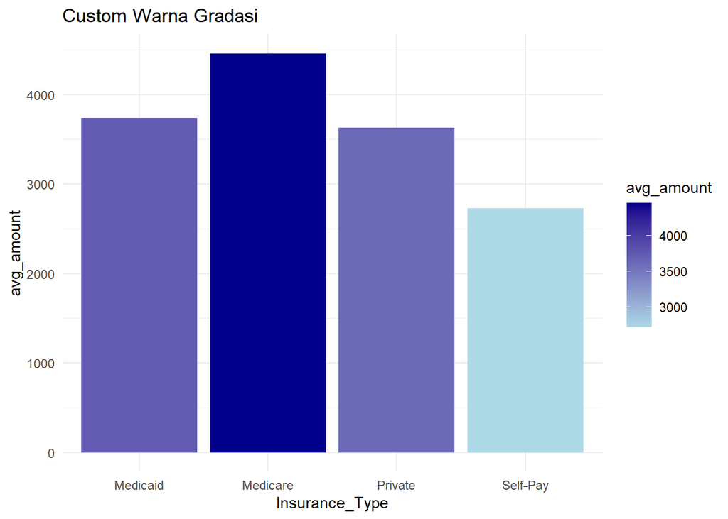

```r
# Warna gradasi
avg_by_insurance <- data %>%
  group_by(Insurance_Type) %>%              # Mengelompokkan data berdasarkan jenis asuransi
  summarise(avg_amount = mean(Avg_Billing_Amount))  # Menghitung rata-rata biaya tagihan untuk setiap jenis asuransi


ggplot(avg_by_insurance, aes(x = Insurance_Type, y = avg_amount, fill = avg_amount)) +
  geom_bar(stat = "identity") +
  scale_fill_gradient(low = "lightblue", high = "darkblue") +
  labs(title = "Custom Warna Gradasi") +
  theme_minimal()
```

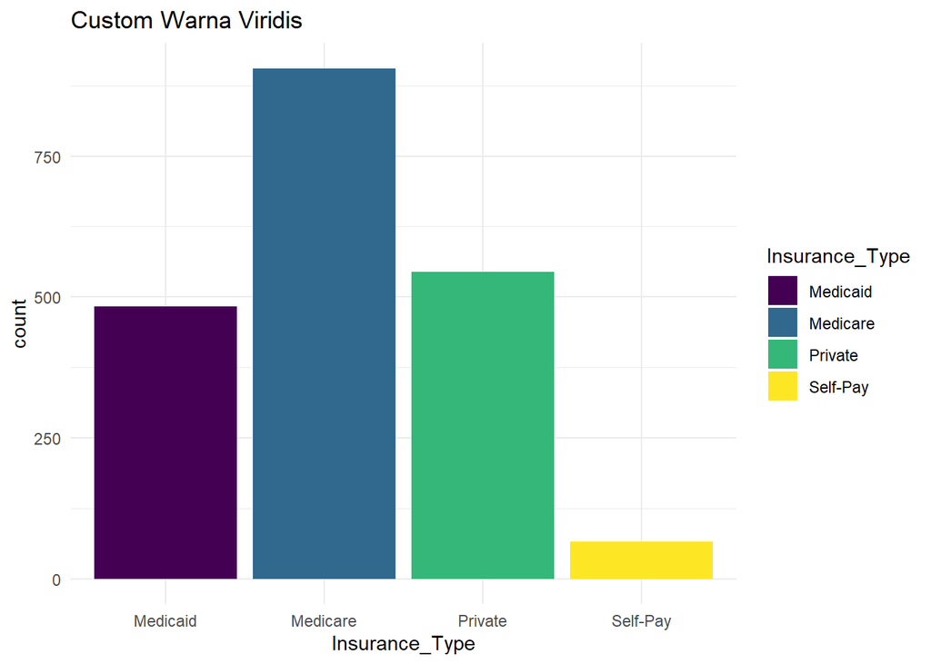

```r
# Warna Viridis (color blind friendly)
ggplot(data, aes(x = Insurance_Type, fill = Insurance_Type)) +
  geom_bar() +
  scale_fill_viridis_d(option = "D") +  # option: A, B, C, D, E
  labs(title = "Custom Warna Viridis") +
  theme_minimal()
```

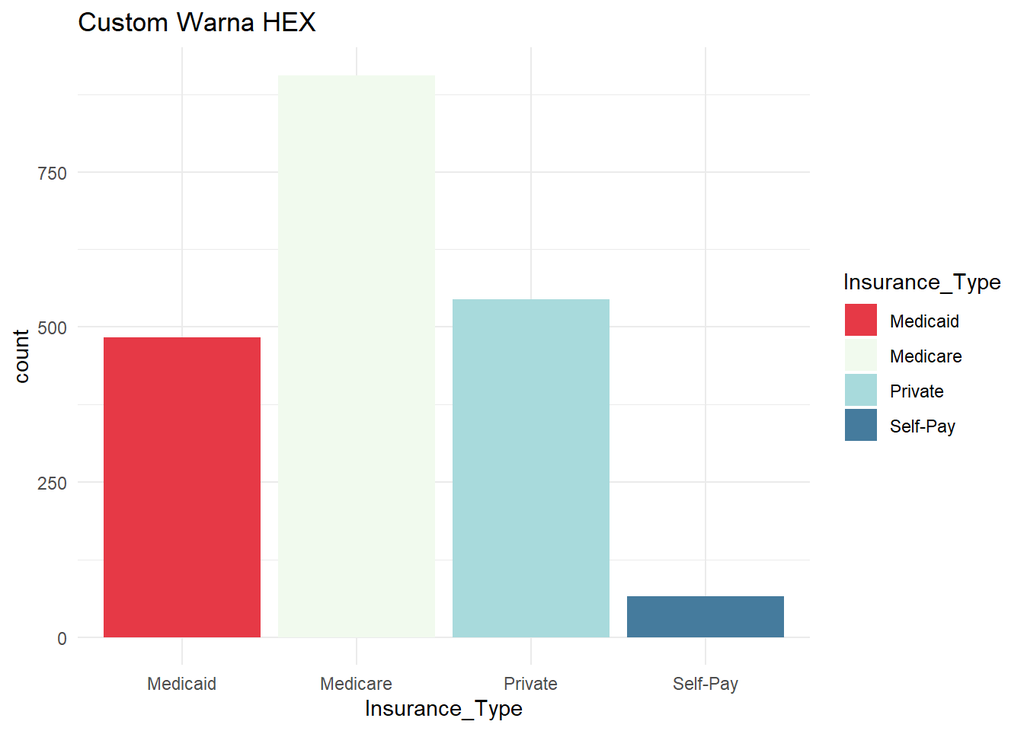

```r
# Warna HEX code
ggplot(data, aes(x = Insurance_Type, fill = Insurance_Type)) +
  geom_bar() +
  scale_fill_manual(values = c("#E63946", "#F1FAEE", "#A8DADC", "#457B9D")) +
  labs(title = "Custom Warna HEX") +
  theme_minimal()
```

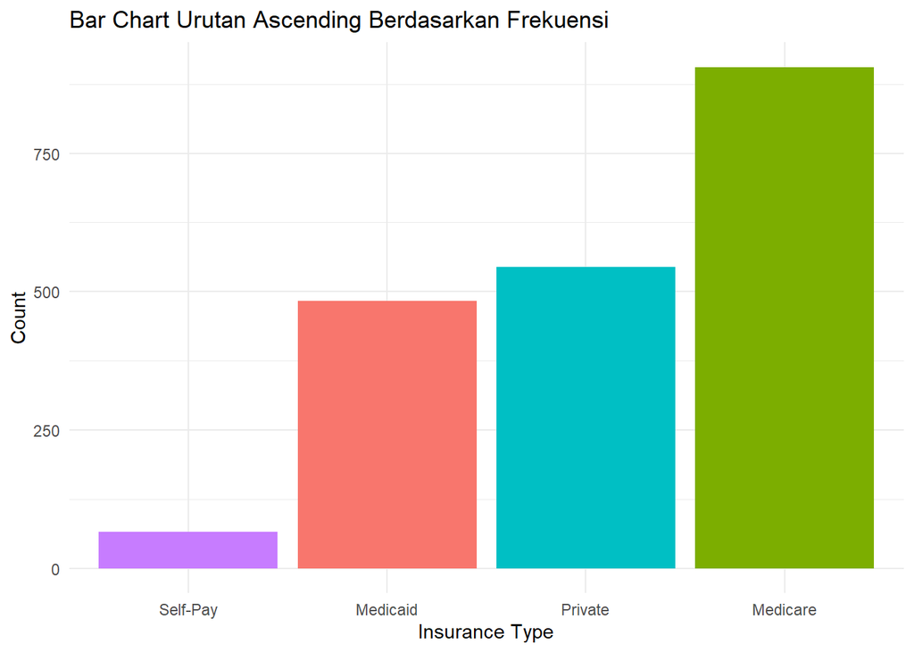

```r
# Urutan Ascending berdasarkan nilai
insurance_count <- data %>%
  count(Insurance_Type) %>%   # Frekuensi tiap jenis asuransi
  arrange(n)                  # Urut berdasarkan frekuensi


ggplot(insurance_count, aes(x = reorder(Insurance_Type, n), y = n, fill = Insurance_Type)) +
  geom_bar(stat = "identity") +
  labs(title = "Bar Chart Urutan Ascending Berdasarkan Frekuensi",
       x = "Insurance Type", y = "Count") +
  theme_minimal() +
  theme(legend.position = "none")
```

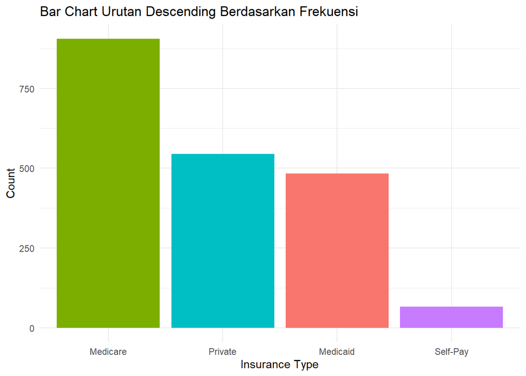

```r
# Urutan Descending Berdasarkan Nilai (n di reorder minus ya)
ggplot(insurance_count, aes(x = reorder(Insurance_Type, -n), y = n, fill = Insurance_Type)) +
  geom_bar(stat = "identity") +
  labs(title = "Bar Chart Urutan Descending Berdasarkan Frekuensi",
       x = "Insurance Type", y = "Count") +
  theme_minimal() +
  theme(legend.position = "none")
```

`reorder(Insurance_Type, -n)`: urutkan kategori dari besar ke kecil

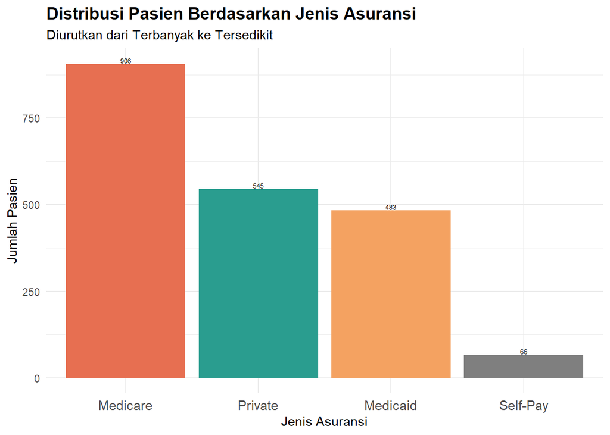

```r
insurance_count <- data %>%
  count(Insurance_Type) %>%
  arrange(n)

ggplot(insurance_count, aes(x = reorder(Insurance_Type, -n), y = n, fill = Insurance_Type)) +
  geom_bar(stat = "identity") +
  geom_text(aes(label = n), vjust = -0.2, size = 2) +
  scale_fill_manual(values = c("Private" = "#2A9D8F",
                                "Medicare" = "#E76F51",
                                "Medicaid" = "#F4A261",
                                "Uninsured" = "#E9C46A")) +
  labs(title = "Distribusi Pasien Berdasarkan Jenis Asuransi",
       subtitle = "Diurutkan dari Terbanyak ke Tersedikit",
       x = "Jenis Asuransi",
       y = "Jumlah Pasien") +
  theme_minimal() +
  theme(legend.position = "none",
        plot.title = element_text(face = "bold", size = 14),
        axis.text.x = element_text(size = 11))
```

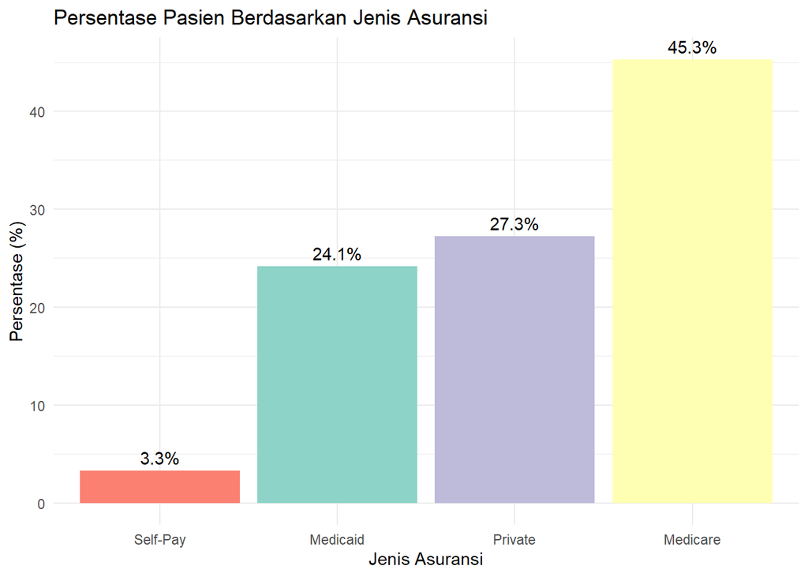

```r
insurance_pct <- data %>%
  count(Insurance_Type) %>%              # Menghitung jumlah observasi untuk setiap jenis asuransi
  mutate(pct = n / sum(n) * 100)          # Menghitung persentase tiap jenis asuransi terhadap total data


ggplot(insurance_pct, aes(x = reorder(Insurance_Type, pct),
                          y = pct,
                          fill = Insurance_Type)) +
  geom_bar(stat = "identity") +
  geom_text(aes(label = paste0(round(pct, 1), "%")),
            vjust = -0.5) +
  scale_fill_brewer(palette = "Set3") +
  labs(title = "Persentase Pasien Berdasarkan Jenis Asuransi",
       x = "Jenis Asuransi",
       y = "Persentase (%)") +
  theme_minimal() +
  theme(legend.position = "none")
```

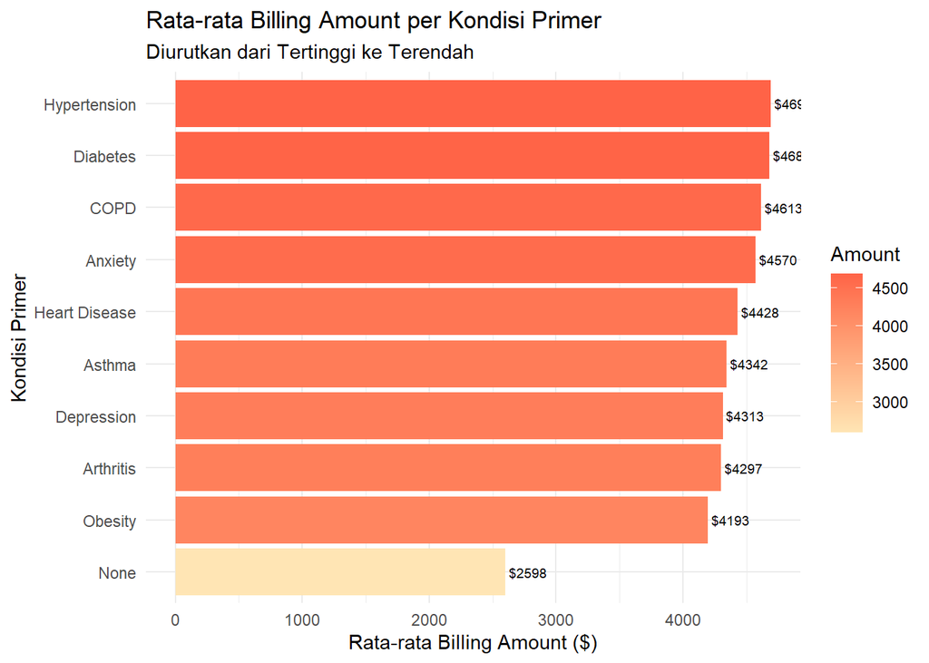

```r
# Horizontal Bar Chart

avg_billing <- data %>%
  group_by(Primary_Condition) %>%                         # Mengelompokkan data berdasarkan kondisi utama pasien
  summarise(Avg_Amount = mean(Avg_Billing_Amount,
                              na.rm = TRUE)) %>%          # Menghitung rata-rata biaya tagihan per kondisi (mengabaikan NA)
  arrange(desc(Avg_Amount))                                # Mengurutkan hasil dari rata-rata biaya tertinggi ke terendah


ggplot(avg_billing, aes(x = reorder(Primary_Condition, Avg_Amount),
                        y = Avg_Amount,
                        fill = Avg_Amount)) +
  geom_bar(stat = "identity") +
  geom_text(aes(label = paste0("$", round(Avg_Amount, 0))), #tanpa spasi, round 0 = bulatkan
            hjust = -0.09, size = 2.5) +
  scale_fill_gradient(low = "#FFE5B4", high = "#FF6347") +
  coord_flip() +
  labs(title = "Rata-rata Billing Amount per Kondisi Primer",
       subtitle = "Diurutkan dari Tertinggi ke Terendah",
       x = "Kondisi Primer",
       y = "Rata-rata Billing Amount ($)",
       fill = "Amount") +
  theme_minimal() +
  theme(legend.position = "right")
```

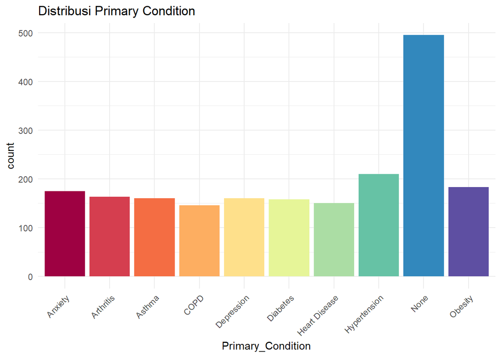

```r
# Rotasi Label Axis
ggplot(data, aes(x = Primary_Condition, fill = Primary_Condition)) +
  geom_bar() +
  scale_fill_brewer(palette = "Spectral") +
  labs(title = "Distribusi Primary Condition") +
  theme_minimal() +
  theme(axis.text.x = element_text(angle = 45, hjust = 1),
        legend.position = "none")
```

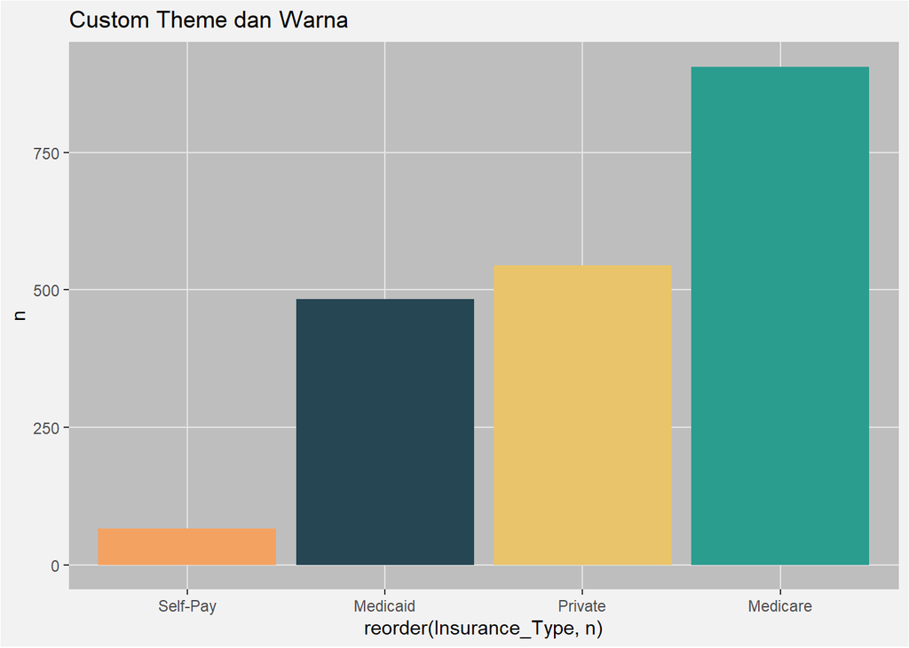

```r
# Kostumisasi Background
ggplot(insurance_count, aes(x = reorder(Insurance_Type, n),
                            y = n,
                            fill = Insurance_Type)) +
  geom_bar(stat = "identity") +
  scale_fill_manual(values = c("#264653", "#2A9D8F", "#E9C46A", "#F4A261")) +
  labs(title = "Custom Theme dan Warna") +
  theme(
    panel.background = element_rect(fill = "gray"), # background area plot
    panel.grid.major = element_line(color = "gray90"), # garis mayor
    panel.grid.minor = element_blank(),
    plot.background = element_rect(fill = "gray95"), # background seluruh plot termasuk judul
    legend.position = "none")
```

## Stacked Bar Chart

Melihat komposisi / kontribusi bagian terhadap total

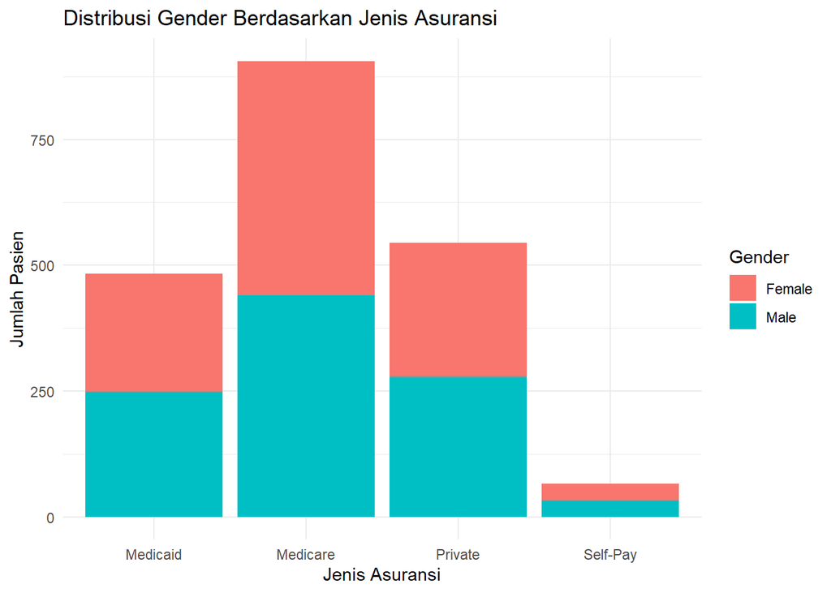

```r
ggplot(data, aes(x = Insurance_Type, fill = Gender)) +
  geom_bar() +
  labs(title = "Distribusi Gender Berdasarkan Jenis Asuransi",
       x = "Jenis Asuransi",
       y = "Jumlah Pasien",
       fill = "Gender") +
  theme_minimal()
```

```r
# fill: warna isi berdasarkan gender
```

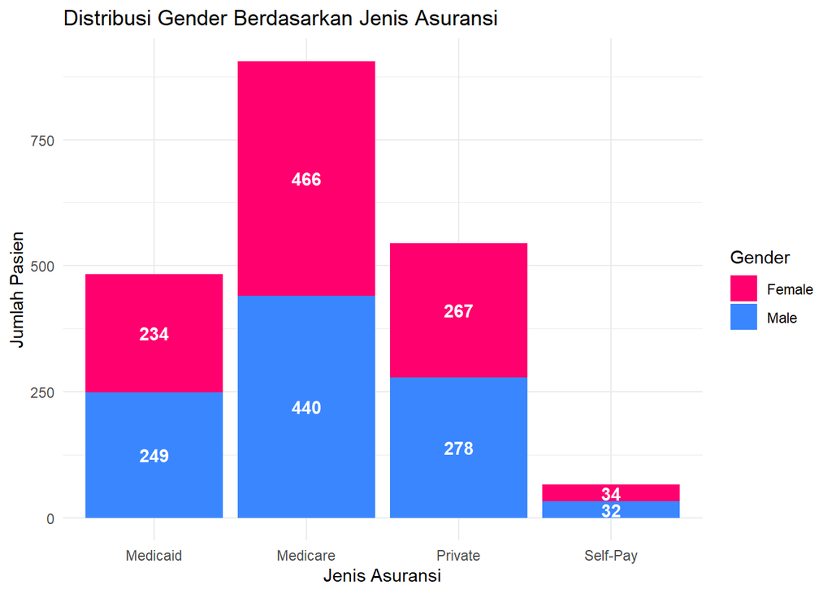

```r
ggplot(data, aes(x = Insurance_Type, fill = Gender)) +
  geom_bar(position = "stack") +
  scale_fill_manual(values = c("Male" = "#3A86FF",
                                "Female" = "#FF006E")) +
  geom_text(stat = 'count',
            aes(label = after_stat(count)),
            position = position_stack(vjust = 0.5),
            color = "white", fontface = "bold") +
  labs(title = "Distribusi Gender Berdasarkan Jenis Asuransi",
       x = "Jenis Asuransi",
       y = "Jumlah Pasien",
       fill = "Gender") +
  theme_minimal()
```

## Grouped Bar Chart

Membandingkan nilai antar kategori secara langsung

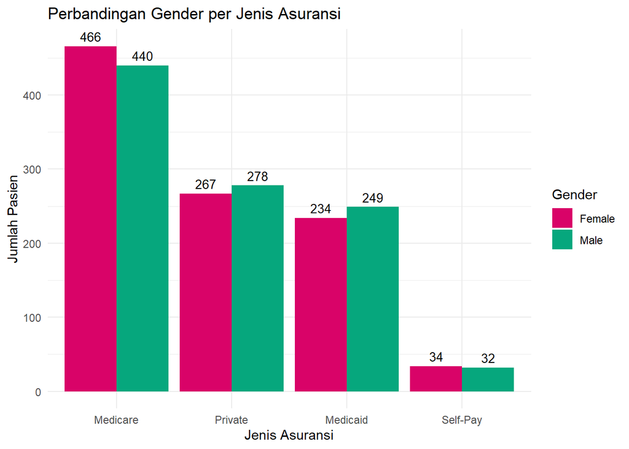

```r
df_summary <- data %>%
  group_by(Insurance_Type, Gender) %>%     # Mengelompokkan data berdasarkan jenis asuransi dan jenis kelamin
  summarise(count = n(),
            .groups = 'drop') %>%          # Menghitung jumlah observasi tiap kombinasi dan menghapus struktur grouping
  arrange(desc(count))                     # Mengurutkan hasil berdasarkan jumlah terbanyak ke tersedikit


ggplot(df_summary, aes(x = reorder(Insurance_Type, -count),
                       y = count,
                       fill = Gender)) +
  geom_bar(stat = "identity", position = "dodge") +
  scale_fill_manual(values = c("Male" = "#06A77D",
                                "Female" = "#D90368")) +
  geom_text(aes(label = count),
            position = position_dodge(width = 0.9),
            vjust = -0.5, size = 3.5) +
  labs(title = "Perbandingan Gender per Jenis Asuransi",
       x = "Jenis Asuransi",
       y = "Jumlah Pasien",
       fill = "Gender") +
  theme_minimal()
```

## Lollipop Chart

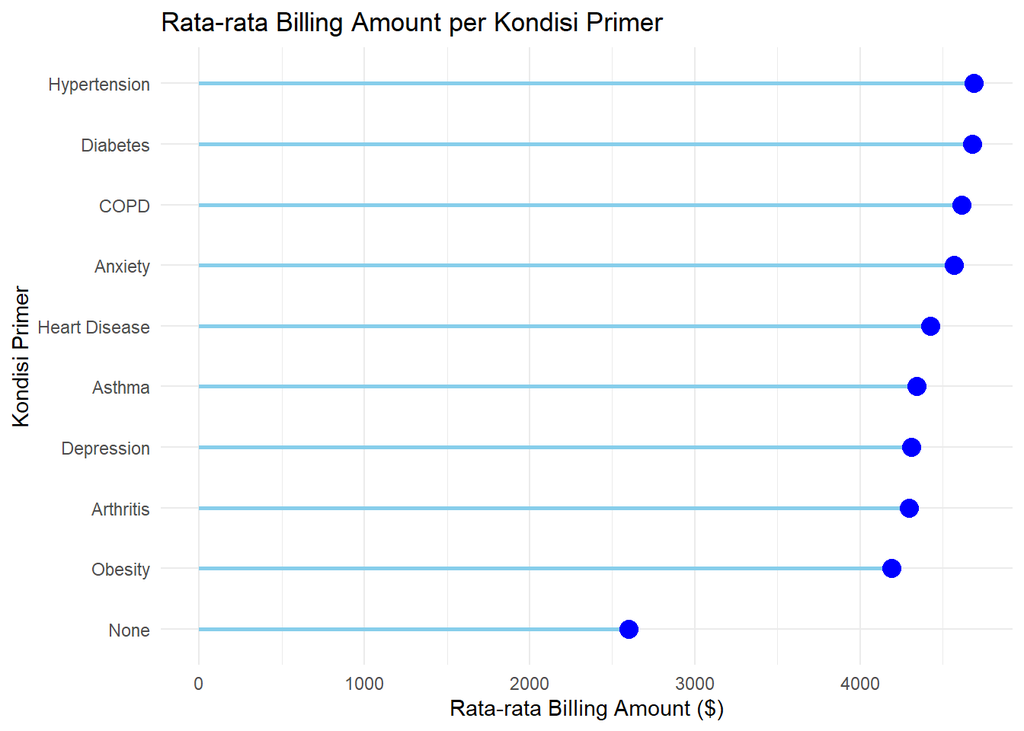

```r
avg_billing <- data %>%
  group_by(Primary_Condition) %>%                         # Mengelompokkan data berdasarkan kondisi utama (Primary_Condition)
  summarise(Avg_Amount = mean(Avg_Billing_Amount,
                              na.rm = TRUE)) %>%          # Menghitung rata-rata biaya tagihan dengan mengabaikan nilai NA
  arrange(desc(Avg_Amount))                                # Mengurutkan hasil dari rata-rata biaya tertinggi ke terendah


# buat garis pakai geom segment
ggplot(avg_billing, aes(x = reorder(Primary_Condition, Avg_Amount), y = Avg_Amount)) +
  geom_segment(aes(x = reorder(Primary_Condition, Avg_Amount),
                   xend = reorder(Primary_Condition, Avg_Amount),
                   y = 0, yend = Avg_Amount),
               color = "skyblue", size = 1) +
  geom_point(color = "blue", size = 4) +
  coord_flip() +
  labs(title = "Rata-rata Billing Amount per Kondisi Primer",
       x = "Kondisi Primer",
       y = "Rata-rata Billing Amount ($)") +
  theme_minimal()
```

# Visualisasi Sebaran Data

## Histogram

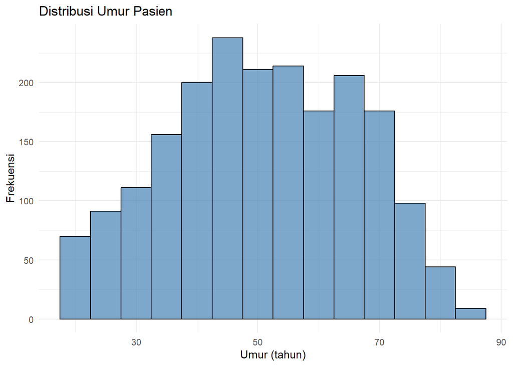

```r
ggplot(data, aes(x = Age)) +
  geom_histogram(binwidth = 5, fill = "steelblue", color = "black", alpha = 0.7) +
  labs(title = "Distribusi Umur Pasien",
       x = "Umur (tahun)",
       y = "Frekuensi") +
  theme_minimal()
```

alpha = 0.3 # Lebih transparan alpha = 0.7  
alpha = 1 # Tidak transparan

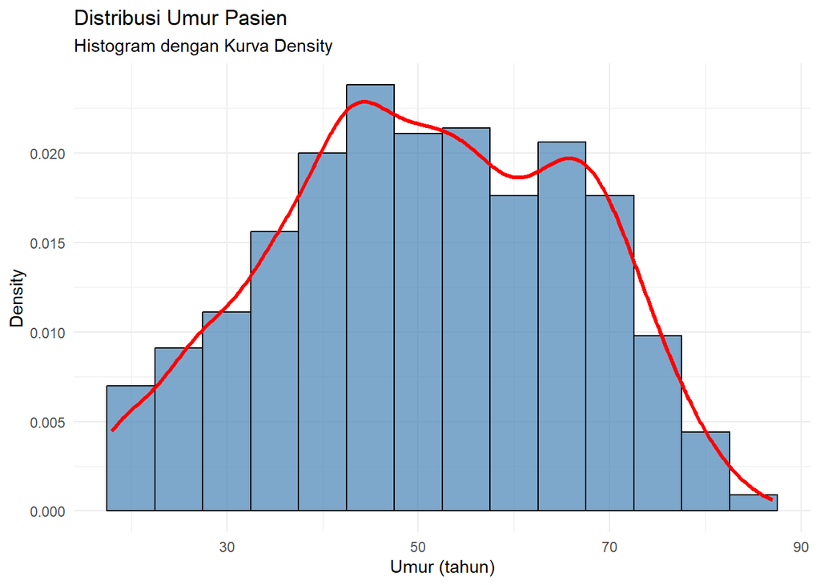

```r
ggplot(data, aes(x = Age)) +
  geom_histogram(aes(y = after_stat(density)),  # Ubah ke density
                 binwidth = 5,
                 fill = "steelblue",
                 color = "black",
                 alpha = 0.7) +
  geom_density(color = "red",                   # Tambah density line
               size = 1.2) +
  labs(title = "Distribusi Umur Pasien",
       subtitle = "Histogram dengan Kurva Density",
       x = "Umur (tahun)",
       y = "Density") +
  theme_minimal()
```

## Density Plot

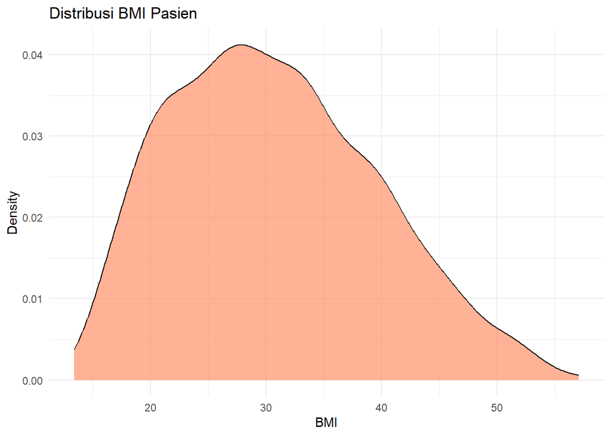

```r
ggplot(data, aes(x = BMI)) +
  geom_density(fill = "coral", alpha = 0.6) +
  labs(title = "Distribusi BMI Pasien",
       x = "BMI",
       y = "Density") +
  theme_minimal()
```

## Boxplot

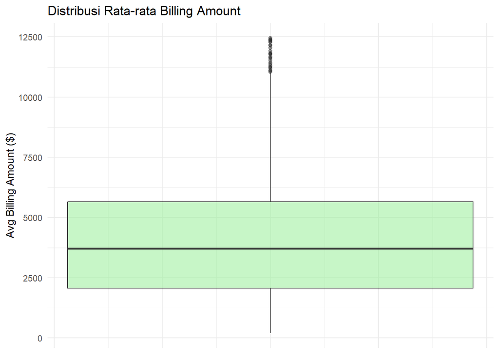

```r
ggplot(data, aes(y = Avg_Billing_Amount)) +
  geom_boxplot(fill = "lightgreen", alpha = 0.5) +
  labs(title = "Distribusi Rata-rata Billing Amount",
       y = "Avg Billing Amount ($)") +
  theme_minimal() +
  theme(axis.text.x = element_blank(),
        axis.ticks.x = element_blank())
```

## Violin Plot

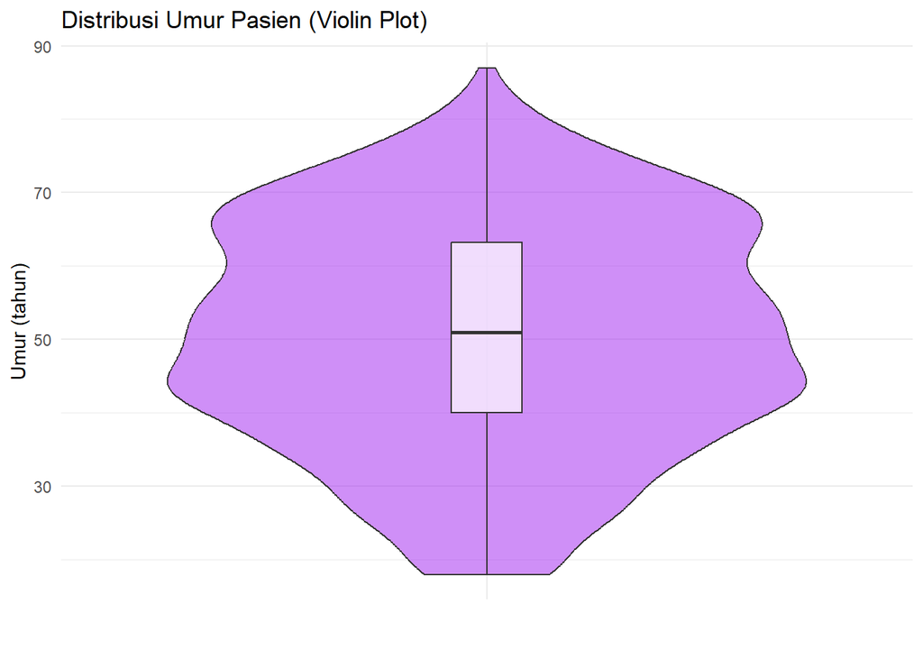

```r
ggplot(data, aes(x = "", y = Age)) +
  geom_violin(fill = "purple", alpha = 0.5) +
  geom_boxplot(width = 0.1, fill = "white", alpha = 0.7) +
  labs(title = "Distribusi Umur Pasien (Violin Plot)",
       x = "",
       y = "Umur (tahun)") +
  theme_minimal()
```

## QQ-Plot (Normalisasi Distribusi BMI)

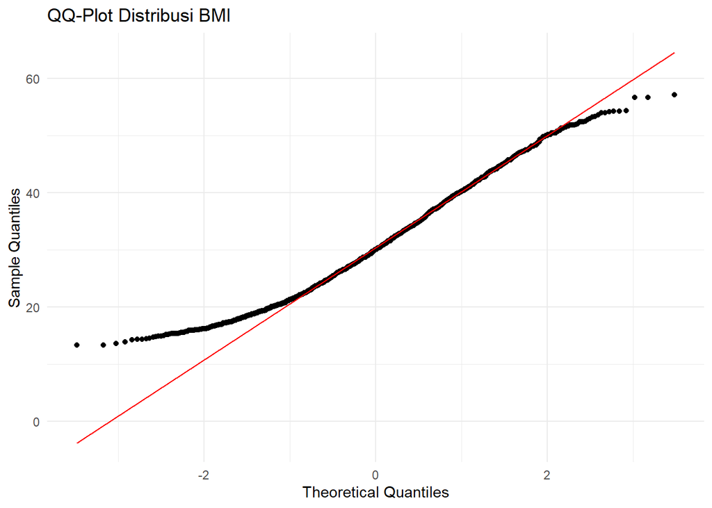

```r
ggplot(data, aes(sample = BMI)) +
  stat_qq() +
  stat_qq_line(color = "red") +
  labs(title = "QQ-Plot Distribusi BMI",
       x = "Theoretical Quantiles",
       y = "Sample Quantiles") +
  theme_minimal()
```

# Visualisasi Perbandingan Sebaran Data

## Multiple Density Plot

BMI berdasarkan gender:

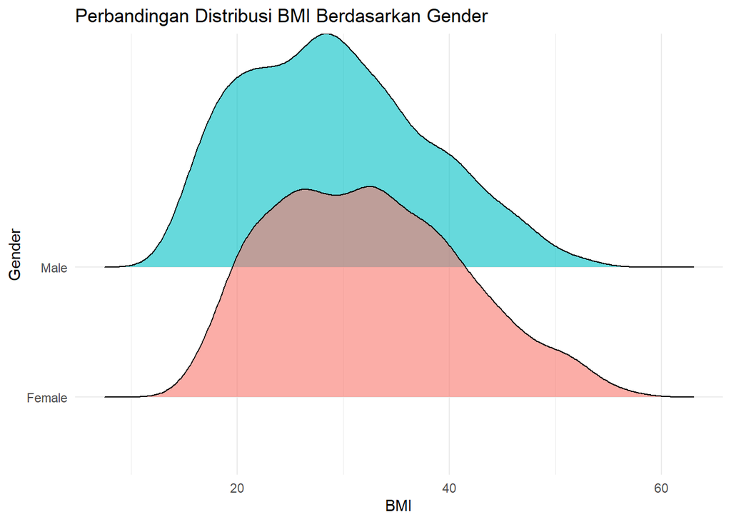

```r
ggplot(data, aes(x = BMI, y = Gender, fill = Gender)) +
  geom_density_ridges(alpha = 0.6) +
  labs(title = "Perbandingan Distribusi BMI Berdasarkan Gender",
       x = "BMI",
       y = "Gender") +
  theme_minimal() +
  theme(legend.position = "none")
```

## Alternatif Multiple Density Plot dengan overlay

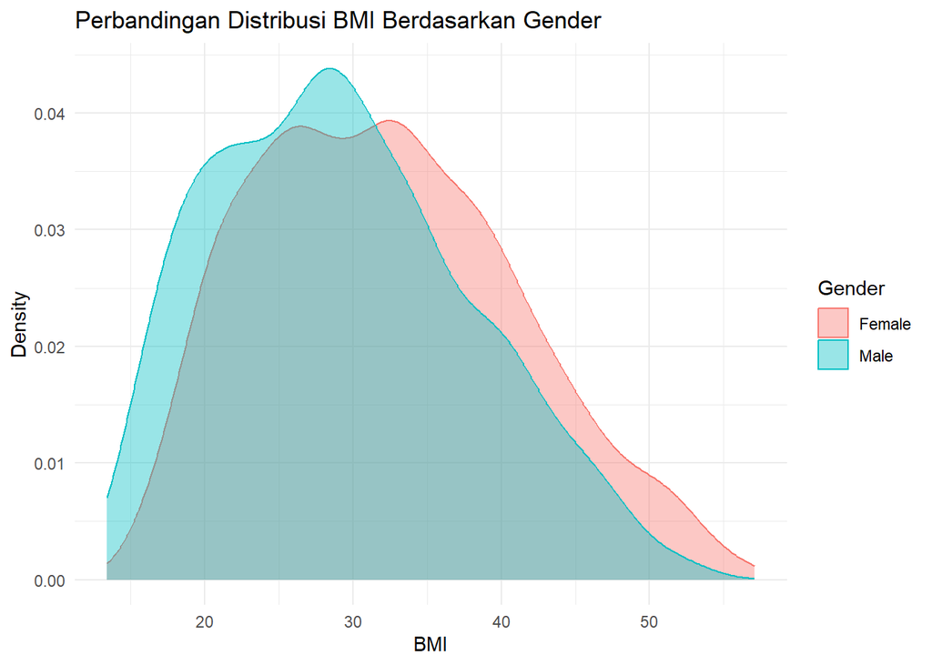

```r
ggplot(data, aes(x = BMI, fill = Gender, color = Gender)) +
  geom_density(alpha = 0.4) +
  labs(title = "Perbandingan Distribusi BMI Berdasarkan Gender",
       x = "BMI",
       y = "Density") +
  theme_minimal()
```

## Multiple Boxplot

Avg Billing Amount Berdasarkan Insurance Type:

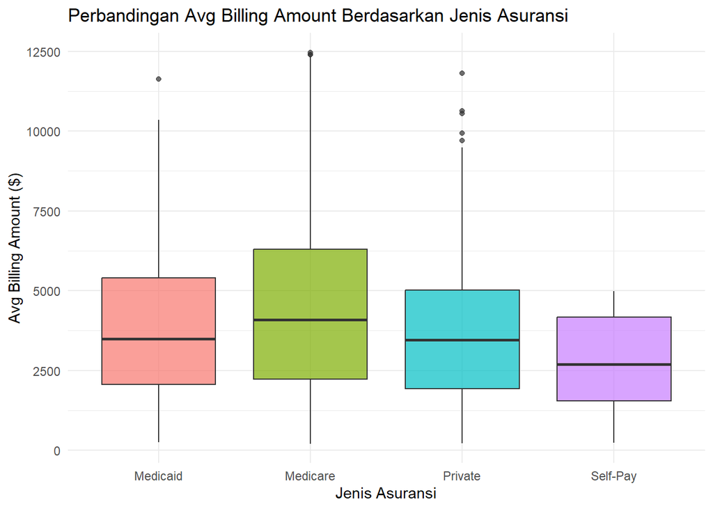

```r
ggplot(data, aes(x = Insurance_Type, y = Avg_Billing_Amount, fill = Insurance_Type)) +
  geom_boxplot(alpha = 0.7) +
  labs(title = "Perbandingan Avg Billing Amount Berdasarkan Jenis Asuransi",
       x = "Jenis Asuransi",
       y = "Avg Billing Amount ($)") +
  theme_minimal() +
  theme(legend.position = "none")
```

## Multiple Violin Plot

Umur Berdasarkan Primary Condition:

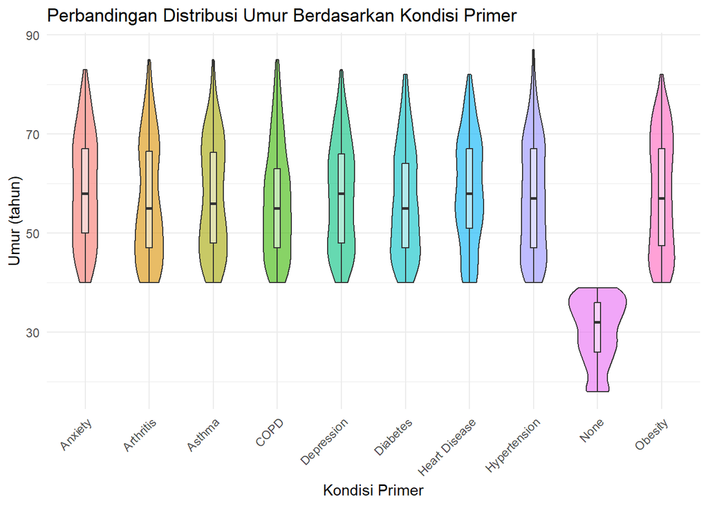

```r
ggplot(data, aes(x = Primary_Condition, y = Age, fill = Primary_Condition)) +
  geom_violin(alpha = 0.6) +
  geom_boxplot(width = 0.1, fill = "white", alpha = 0.5) +
  labs(title = "Perbandingan Distribusi Umur Berdasarkan Kondisi Primer",
       x = "Kondisi Primer",
       y = "Umur (tahun)") +
  theme_minimal() +
  theme(axis.text.x = element_text(angle = 45, hjust = 1),
        legend.position = "none")
```

# Visualisasi Tambahan

## Word Cloud

```r
#install.packages("wordcloud")    # Library utama untuk word cloud
#install.packages("wordcloud2")   # Library untuk word cloud interaktif
#install.packages("RColorBrewer") # Library untuk color palette
#install.packages("tm")           # Library untuk text mining
```

```r
library(wordcloud)      # Aktifkan library wordcloud
library(wordcloud2)     # Aktifkan library wordcloud2
library(RColorBrewer)   # Aktifkan library warna
library(tm)             # Aktifkan library text mining
library(dplyr)          # Aktifkan library manipulasi data
```

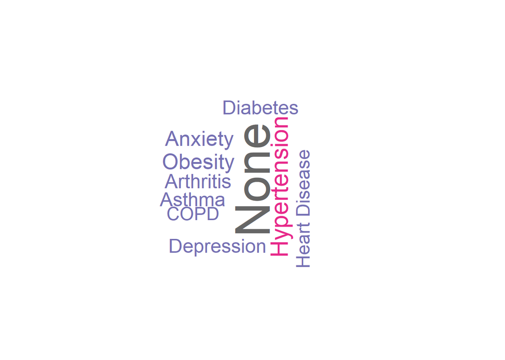

```r
condition_freq <- data %>%
  count(Primary_Condition) %>%              #Hitung jumlah setiap kondisi
  arrange(desc(n))

wordcloud(
  words = condition_freq$Primary_Condition,  # Kata yang ditampilkan (kolom Primary_Condition)
  freq = condition_freq$n,                   # Frekuensi/ukuran kata (kolom n)
  min.freq = 1,                              # Tampilkan kata dengan frekuensi minimum 1
  max.words = 200,                           # Maksimal 200 kata yang ditampilkan
  random.order = FALSE,                      # FALSE = kata frekuensi tinggi di tengah, TRUE = acak
  rot.per = 0.35,                           # 35% kata akan dirotasi 90 derajat (vertikal)
  colors = brewer.pal(8, "Dark2")
)
```

```r
data %>% filter(!is.na(Primary_Condition))
```

| PatientID | Age | Gender | State | City | Height_cm | Weight_kg | BMI | Insurance_Type | Primary_Condition | Num_Chronic_Conditions | Annual_Visits | Avg_Billing_Amount | Last_Visit_Date | Days_Since_Last_Visit | Preventive_Care_Flag |
| --- | --- | --- | --- | --- | --- | --- | --- | --- | --- | --- | --- | --- | --- | --- | --- |
| P10000 | 64 | Male | GA | Unknown | 151 | 115 | 50.4 | Private | Arthritis | 3 | 7 | 2995.0 | 2025-07-18 | 186 | 0 |
| P10001 | 59 | Male | OH | Unknown | 189 | 68 | 19.0 | Medicare | Depression | 1 | 8 | 1209.0 | 2025-12-12 | 39 | 0 |
| P10002 | 58 | Female | PA | Unknown | 156 | 91 | 37.4 | Private | Asthma | 1 | 4 | 999.0 | 2025-09-16 | 126 | 0 |
| P10003 | 43 | Female | GA | Unknown | 152 | 92 | 39.8 | Medicare | Hypertension | 1 | 6 | 5638.5 | 2025-04-09 | 286 | 1 |
| P10004 | 53 | Female | NC | Unknown | 167 | 51 | 18.3 | Medicaid | Asthma | 1 | 4 | 5796.0 | 2025-03-07 | 319 | 0 |
| P10005 | 73 | Male | OH | Unknown | 160 | 120 | 46.9 | Medicare | Anxiety | 3 | 9 | 2397.5 | 2025-05-13 | 252 | 1 |
| P10006 | 34 | Male | PA | Unknown | 161 | 51 | 19.7 | Private | None | 0 | 3 | 4668.0 | 2025-06-11 | 223 | 1 |
| P10007 | 64 | Female | MI | Unknown | 177 | 102 | 32.6 | Private | Arthritis | 3 | 1 | 9942.5 | 2025-05-13 | 252 | 0 |
| P10008 | 61 | Female | PA | Unknown | 171 | 86 | 29.4 | Private | Arthritis | 2 | 7 | 1036.0 | 2025-05-14 | 251 | 1 |
| P10009 | 34 | Male | FL | Tampa | 182 | 111 | 33.5 | Medicare | None | 0 | 1 | 4602.0 | 2026-01-09 | 11 | 0 |

[output cut: 1990 more lines]

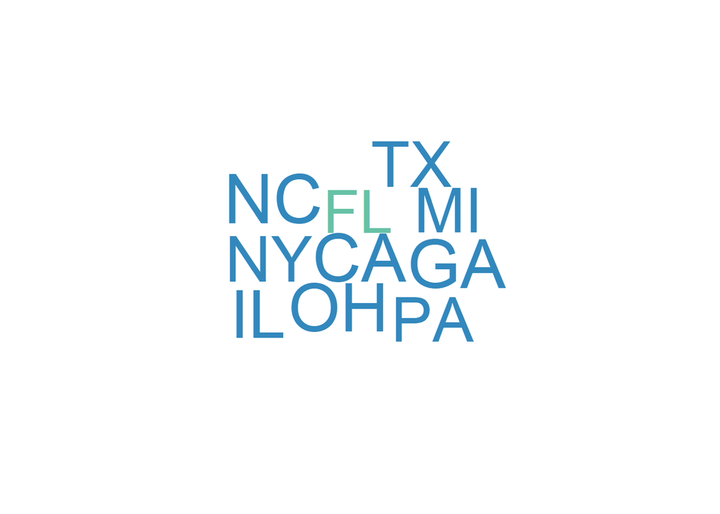

```r
#install.packages("ggwordcloud")
library(ggwordcloud)

condition_freq <- data %>%
  count(Primary_Condition) %>%
  arrange(desc(n))

# State
state_freq <- data %>% count(State)
wordcloud(state_freq$State, state_freq$n,
          colors = brewer.pal(8, "Spectral"),
          main = "State")
```

## Map Chart

```r
#install.packages("mapdata")
library(ggplot2)
library(dplyr)
library(maps)
library(viridis)
library(scales)
library(mapdata)
```

```r
# 'region' pada data peta berisi NAMA LENGKAP negara bagian
# dalam huruf kecil (misal: "california", "new york")
# Kolom ini akan menjadi kunci utama saat menggabungkan data

# Get US state map data
us_states <- map_data("state")

state_abbrev <- data.frame(
  # Singkatan negara bagian (sama seperti di data pasien)
  abbreviation = state.abb,

  # Nama lengkap negara bagian (lowercase)
  # Harus lowercase agar cocok dengan kolom 'region' di peta
  region = tolower(state.name),
  stringsAsFactors = FALSE)

# Hitung jumlah pasien per state
patient_count <- data %>%
  group_by(State) %>%
  summarise(
    count = n(),
    avg_age = mean(Age, na.rm = TRUE),
    avg_bmi = mean(BMI, na.rm = TRUE),
    avg_visits = mean(Annual_Visits, na.rm = TRUE),
    avg_billing = mean(Avg_Billing_Amount, na.rm = TRUE),
    .groups = "drop"
  ) %>%
  rename(abbreviation = State) %>%
  left_join(state_abbrev, by = "abbreviation")

# Merge dengan map data
map_data_merged <- us_states %>%
  left_join(patient_count, by = "region")
```

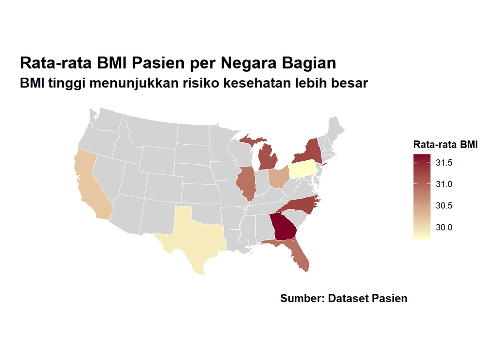

```r
# Rata-rata BMI

plot2 <- ggplot(map_data_merged, aes(x = long, y = lat, group = group)) +
  geom_polygon(
    aes(fill = avg_bmi),
    color = "white",
    linewidth = 0.3
  ) +
  scale_fill_gradient(
    low = "#FFFFCC",
    high = "#800026",
    name = "Rata-rata BMI",
    na.value = "lightgray"
  ) +
  coord_map("albers", lat0 = 39, lat1 = 47) +
  labs(
    title = "Rata-rata BMI Pasien per Negara Bagian",
    subtitle = "BMI tinggi menunjukkan risiko kesehatan lebih besar",
    caption = "Sumber: Dataset Pasien"
  ) +
  theme_void() +
  theme(
    title = element_text(size = 14, face = "bold", hjust = 0.5),
    subtitle = element_text(size = 10, color = "gray50", hjust = 0.5),
    caption = element_text(size = 8, color = "gray60", hjust = 0.5),
    legend.position = "right",
    legend.title = element_text(size = 10, face = "bold"),
    plot.margin = margin(20, 20, 20, 20)
  )

print(plot2)
```

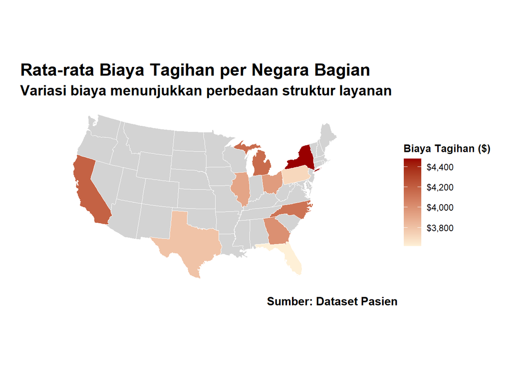

```r
plot4 <- ggplot(map_data_merged, aes(x = long, y = lat, group = group)) +
  geom_polygon(
    aes(fill = avg_billing),
    color = "white",
    linewidth = 0.3
  ) +
  scale_fill_gradient(
    low = "#FEF0D7",
    high = "#990000",
    name = "Biaya Tagihan ($)",
    na.value = "lightgray",
    labels = dollar
  ) +
  coord_map("albers", lat0 = 39, lat1 = 47) +
  labs(
    title = "Rata-rata Biaya Tagihan per Negara Bagian",
    subtitle = "Variasi biaya menunjukkan perbedaan struktur layanan",
    caption = "Sumber: Dataset Pasien"
  ) +
  theme_void() +
  theme(
    title = element_text(size = 14, face = "bold", hjust = 0.5),
    subtitle = element_text(size = 10, color = "gray50", hjust = 0.5),
    caption = element_text(size = 8, color = "gray60", hjust = 0.5),
    legend.position = "right",
    legend.title = element_text(size = 10, face = "bold"),
    plot.margin = margin(20, 20, 20, 20)
  )

print(plot4)
```